# Neuromyelitis Optica Spectrum Disorders

28 augusti 2017

# 1 Executive Summary

**1.** The incidence rate has increased steadily from 1991 to 2013  
**2.** The typical patient is a 40-year old female  
**3.** Time from onset to diagnosis is approximately 1 year  
**4.** CSF analysis is associated with a high degree of false negative results  
**5.** Relapses occur in 3 out of 4 patients.  
**6.** Relapses are mainly treated with steroids  
**7.** Mortality is low and in all (three) cases due to infection

# 2 Data

**Table 1. Current data**

| Patients (n) | 103 |
| --- | --- |
| Mean follow up time (years) | 11 |

# 3 Incidence Rate

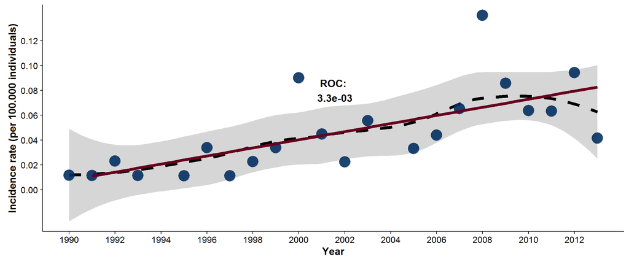

# 4 Disease at Onset

## 4.1 Age & sex

**Fig 2. Age and sex distribution at onset**

[figure not shown]

**Fig 2.** *Figure 2A reports the age distribution in the patient cohort for each sex. Both sexes have bell-shaped histograms with mean at 40 years of age. Hence, this patient cohort has, in this aspect, similarites with previously published data. Fig 2B reports the sex distribution in the dataset, which is also in line with previously published data.*

**Table 2. Descriptive statistics: age at onset**

| Mean | SD | Median | Q25 | Q75 |
| --- | --- | --- | --- | --- |
| 40 | 17 | 38 | 26 | 54 |

## 4.2 Clinical features

**Fig 3. Clinical features of patients (regardless of timing)**

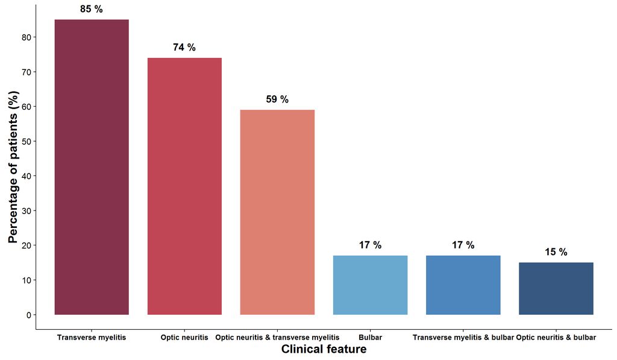

**Fig 3.** *Figure reports the clinical features of patients regardless of timing.*

**Table 3. Number of patients with a particular symptom divided by type of NMO**

| Type | Transverse Myelitis | Optic Neuritis | Transverse Myelitis & Optic Neuritis |
| --- | --- | --- | --- |
| Relapsing | 31 | 25 | 5 |
| Non-relapsing | 21 | 13 | 7 |

**Comment:** *Data for relapsing type refers to the number of patients who presented with the particular symptom. Data for the non-relapsing type refers to data for patients who had the particular symptom (combinations of symptoms is not taken into consideration).*

## 4.3 Time from onset to diagnosis

**Fig 4. Time from onset to diagnosis**

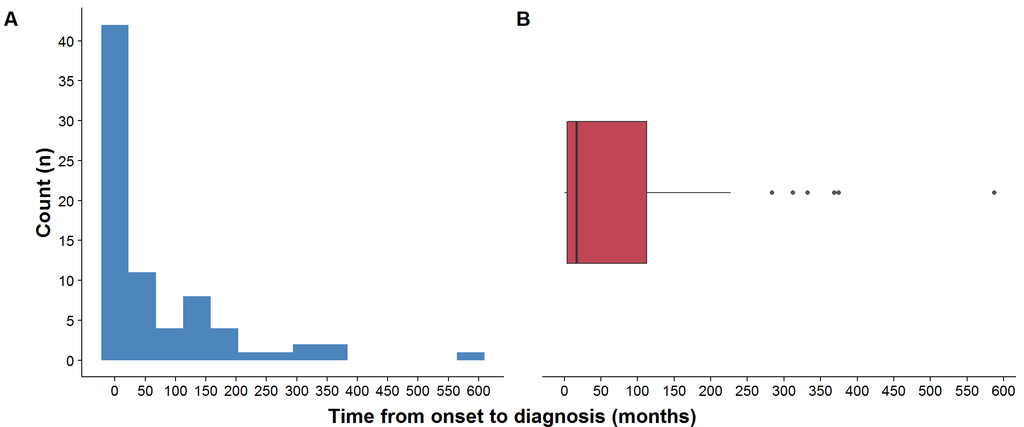

**Table 4. Descriptive statistics: time from onset to diagnosis**

| Mean | SD | Median | Q25 | Q75 |
| --- | --- | --- | --- | --- |
| 70 | 110 | 16 | 3.8 | 113 |

## 4.4 Cerebrospinal fluid diagnostical examination

**Fig 5. Fraction of true positive and false negative examinations in the cerebrospinal fluid**

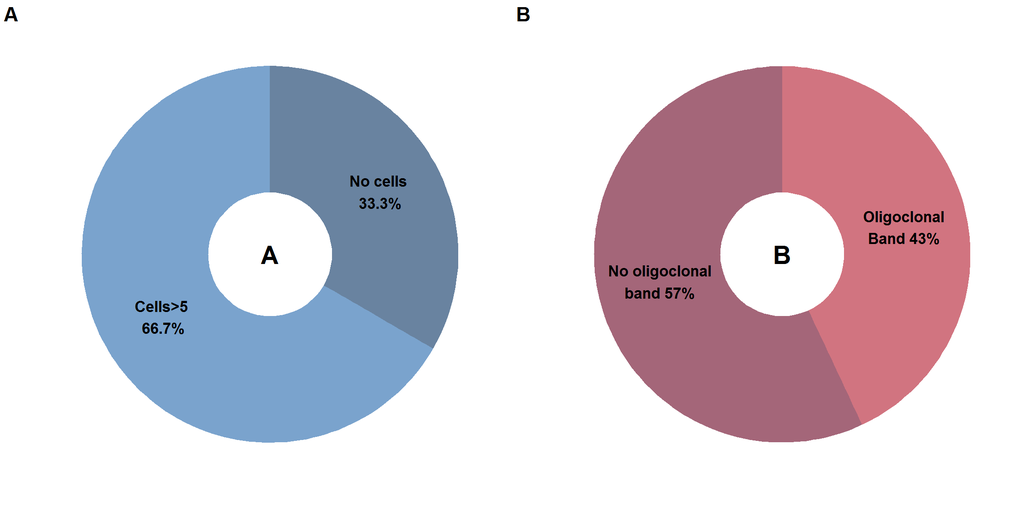

**Fig 5.** *Figure reports the fraction of true positive (cells, band) and false negative (no cells, no band) for two types of examinations of the cerebrospinal fluid (CSF). Figure 3A reports cell detection while Figure 3B reports detection of oligoclonal bands. The fraction of false negative tests for both examinations are substantial.*

# 5 Inhibitory Drug Treatment

**Fig 6. Inhibitory drugs**

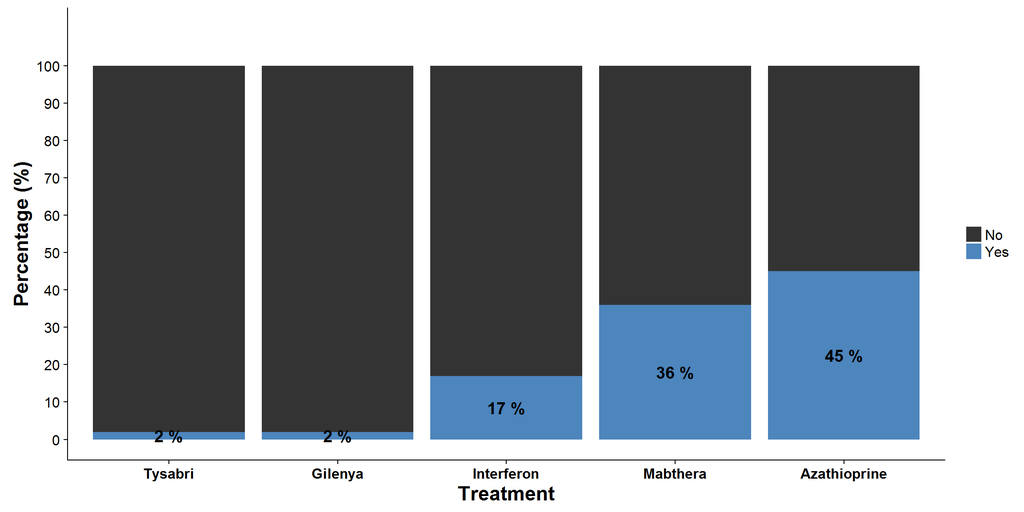

**Table 5. Comorbidites**

| Comorbidity | Count (n) | Percentage of cohort |
| --- | --- | --- |
| RA | 5 | 0.049 |
| Hypothyreosis | 6 | 0.058 |
| Psoriasis | 3 | 0.029 |
| Sarcoidosis | 2 | 0.019 |

# 6 Relapse

|  | Percentage (%) |
| --- | --- |
| Relapse | 73.53 |

## 6.1 Relapse drug treatment

**Fig 10. Distribution of drugs administrated during relpase**

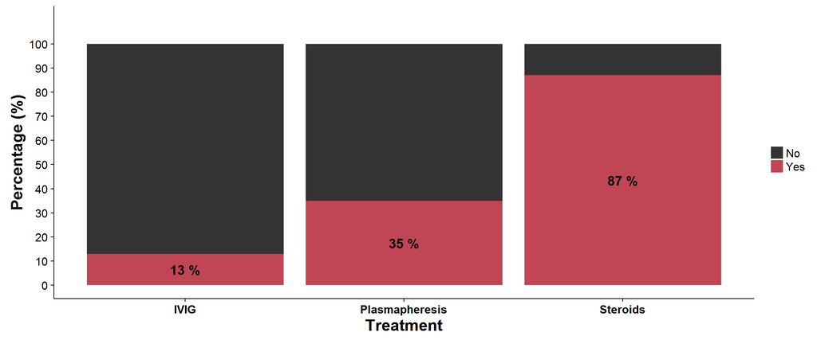

**Fig 10.** *Figure reports the usage of drugs administrated during relapse of NMO. Steroids are most commonly used.*

# 7 Outcome

**Table 7. Mortality**

| Status | (%) |
| --- | --- |
| Alive | 97 |
| Dead | 3 |

**Comment:** *All three cases of death were caused by infection (sepsis or pneumonia).*

# 8 Bibliography

**[1]** *R Core Team (2016). R: A language and environment for statistical computing. R Foundation for Statistical Computing, Vienna, Austria. URL htts://www.R-project.*

**[2]** _Matt Dowle and Arun Srinivasan (2017). data.table: Extension of `data.frame`. R package version 1.10.4.https://CRAN.R-project.org/package=data.table._

# 9 Setup

```r
# #Saving
# ggsave("incidens_plot.jpg", incidens_plot, width=14, height=7, dpi=1000)
# ggsave("age_plot.jpg", age_plot, width=14, height=7, dpi=1000)
# ggsave("pie_chart_plot_function.jpg", pie_chart_plot_function, width=7, height = 7, dpi=1000)
# ggsave("symptom_plot.jpg", symptom_plot, width=14, height = 7, dpi=1000)
# ggsave("time_histogram.jpg", time_histogram, width=14, height = 7, dpi=1000)
# ggsave("time_boxplot.jpg", time_boxplot, width=14, height = 7, dpi=1000)
# ggsave("pie_chart_cells.jpg", pie_chart_cells, width=7, height = 7, dpi=1000)
# ggsave("pie_chart_bands.jpg", pie_chart_bands, width=7, height = 7, dpi=1000)
# ggsave("inhibitory_treatment.jpg", treatment_plot_function(DT_inhibit_treatment_summary, c("#000000", brewer.pal(11, "RdBu")[c(10)])), width=14, heigh=7, dpi=1000)
# ggsave("relapse_treatment.jpg", treatment_plot_function(DT_relapse_treat_summary, c("#000000", brewer.pal(11, "RdBu")[c(2)])), width=14, height = 7, dpi=1000)
```